# RGoogleAnalytics

Rachael Pai

Sunday, March 22, 2015

**這個分享是使用RGoogleAnalytics 套件獲取GA上的資料。 這樣使用者就可以進一步使用R做 GA 分析**

## Google Analytics

[Google Analytics (GA)](http://www.google.com/analytics/)可以幫助您統計分析您的網站和移動裝置的免費服務。

**GA 網站畫面**

[figure not shown]

**GA 網站畫面**

[figure not shown]

## 先前步驟

- 當然, 你需要先有 GA 帳號 , 然後也已經擁有 GA 數據 , 才有意義

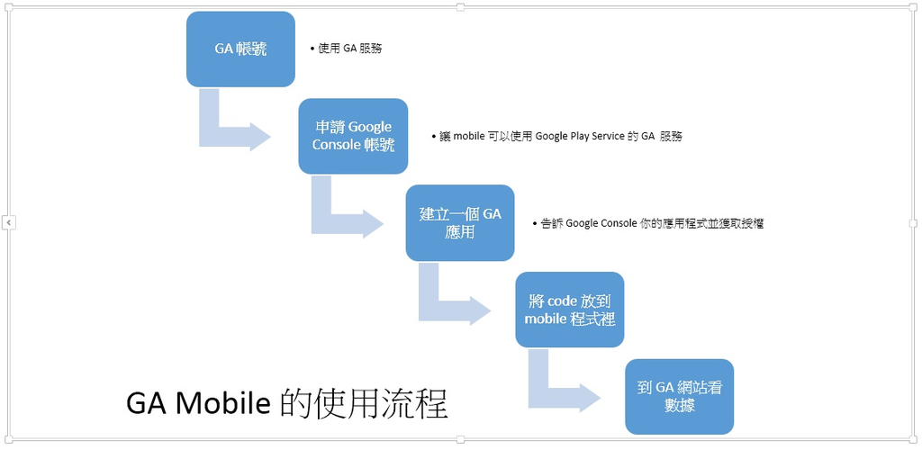

- 而後, 你需要到 [Google Developers Console](https://console.developers.google.com) 申請使用 Google Api 的授權
- 獲得 Google Api 授權後， 記下 Client id 跟 Client Secret

## RGoogleAnalytics Outline

- Install Library
- Authentication - Oath2
- Get Profile
- Get Data

### 安裝

install.packages(“RGoogleAnalytics”)

### 授權

//Using RGoogleAnalytics library

library(RGoogleAnalytics)

//Copy client id and client secret from Google Developers Consol

client.id <- “XXXXXXXX”

client.secret <- “YYYYYYYY”

//Getting Oath using Oath2

oath_token <- Auth(client.id=client.id, client.secret = client.secret)

//Save the token if you want

save(oath_token, file=“oath_token”)

### 獲取報表

Google Analytics 可以設置不同的報表組, 例如: Web 報表， Mobile 報表等。 以 Mobile 為例 不同的 APP 也很有可能有著不同的報表。使用 GetProfiles function 可以列出所有的報表。

// Load if nessesary

load(“oath_token”)

// Check if token validate

ValidateToken(oath_token)

// Getting Profiles

profile <- GetProfiles(oath_token)

profile

### 獲取資料

// if not specify table id in gaExamples.R

ga.table.id <- “ga:79915131”

// Init 將 Query 參數做成 list

query.list <- Init(start.date = “2014-01-01”, end.date = “2014-03-15”, dimensions = “ga:userType”, metrics = “ga:users”, max.result = 500, sort = “ga:users”, filters = NULL, table.id = ga.table.id)

//build the query object 並且做 Validation

ga.query <- QueryBuilder(query.list)

// Get the ReportData

ga.data <- GetReportData(ga.query, oath_token)

ga.data

userrow <- rownames(ga.data)

## 其他相關網站

### 相關的 Google Analytics 連結

- [Query Explore](https://ga-dev-tools.appspot.com/explorer/) 提供網頁介面使用 Core Reporting API (核心報表 API)
- [Dimensions & Metrics Explorer](https://ga-dev-tools.appspot.com/dimensions-metrics-explorer/) Matrics 和 Dimensions 的文件

### RGoogleAnalystics 連結

- [Github](https://github.com/Tatvic/RGoogleAnalytics/)
- [Issues](https://github.com/Tatvic/RGoogleAnalytics/issues)